# Лабораторная работа № 11. Текстовой редактор emacs

НПИбд-03-25

Author

Чжу Ино

Published

2026-10-15

# 1 Цель работы

Познакомиться с операционной системой Linux. Получить практические навыки работы с редактором Emacs.

# 2 Задачи

1. Ознакомиться с теоретическим материалом.
2. Ознакомиться с редактором Emacs.
3. Выполнить упражнения.
4. Ответить на контрольные вопросы.

# 3 Теоретические сведения

## 3.1 Основные термины Emacs

- **Буфер** — объект, представляющий текст.
- **Фрейм** — окно в обычном понимании.
- **Окно** — прямоугольная область фрейма.
- **Область вывода** — строки внизу фрейма.
- **Минибуфер** — для ввода дополнительной информации.
- **Точка вставки** — место вставки/удаления.

## 3.2 Запуск Emacs

```bash
emacs
```

или в фоне:

```bash
emacs &
```

## 3.3 Выход из Emacs

- Меню `File` → `Quit`
- Или `Ctrl+X` `Ctrl+C`

## 3.4 Префиксные клавиши

- `C-` — `Ctrl`
- `M-` — `Meta` (обычно `Alt` или `Esc`)
- `S-` — `Shift`

## 3.5 Основные комбинации клавиш

### 3.5.1 Перемещение курсора

- `C-p` — вверх на строку
- `C-n` — вниз на строку
- `C-f` — вперёд на символ
- `C-b` — назад на символ
- `C-a` — начало строки
- `C-e` — конец строки
- `C-v` — вниз на страницу
- `M-v` — вверх на страницу
- `M-f` — вперёд на слово
- `M-b` — назад на слово
- `M-<` — начало буфера
- `M->` — конец буфера

### 3.5.2 Работа с текстом

- `C-d` — удалить символ перед курсором
- `M-d` — удалить слово
- `C-k` — удалить до конца строки
- `M-k` — удалить до конца предложения
- `C-q` — вставить символ
- `M-q` — выровнять абзац

### 3.5.3 Выделение

- `C-space` — начать выделение
- `C-w` — удалить выделенное
- `M-w` — скопировать выделенное
- `C-y` — вставить из списка удалений

### 3.5.4 Поиск и замена

- `C-s` — поиск вперёд
- `C-r` — поиск назад
- `M-%` — поиск и замена

### 3.5.5 Файлы и буферы

- `C-x C-f` — открыть файл
- `C-x C-s` — сохранить
- `C-x C-b` — список буферов
- `C-x b` — переключить буфер
- `C-x 0` — закрыть окно
- `C-x 1` — закрыть все кроме текущего
- `C-x 2` — разделить по горизонтали
- `C-x o` — перейти в другое окно

# 4 Выполнение лабораторной работы

## 4.1 Установка Emacs

```bash
sudo dnf -y install emacs
emacs --version
```

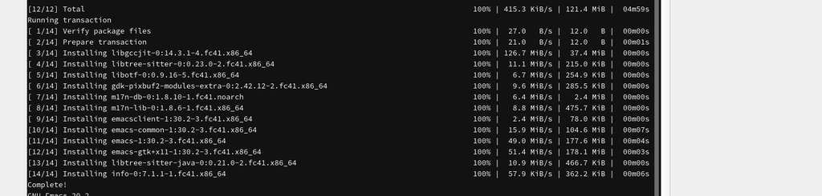

Figure 1: Установка Emacs

## 4.2 Запуск Emacs

```bash
emacs
```

[figure not shown]

Figure 2: Запуск

## 4.3 Выход из Emacs

`Ctrl+X` `Ctrl+C`

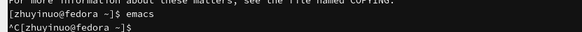

Figure 3: Выход

## 4.4 Открытие файла

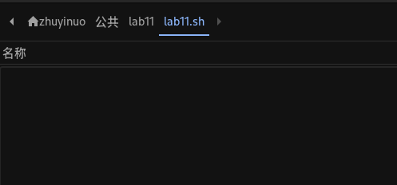

## 4.5 Ввод текста

```
#!/bin/bash
HELL=Hello
function hello {
    LOCAL HELLO=World
    echo $HELLO
}
echo $HELLO
hello
```

[figure not shown]

Figure 5: Ввод

## 4.6 Сохранение

`Ctrl+X` `Ctrl+S`

[figure not shown]

Figure 6: Сохранение

## 4.7 Вырезание строки

`Ctrl+K`

[figure not shown]

Figure 7: Вырезание

## 4.8 Вставка в конец

`Ctrl+Y`

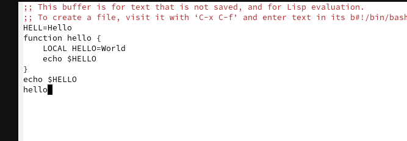

Figure 8: Вставка

## 4.9 Выделение области

`Ctrl+Space`

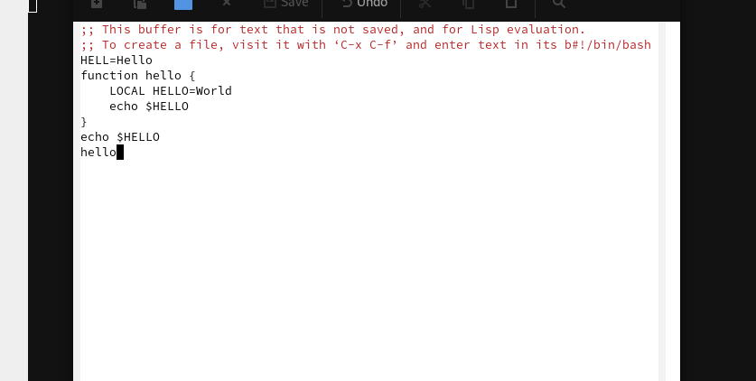

## 4.10 Копирование области

`M-w`

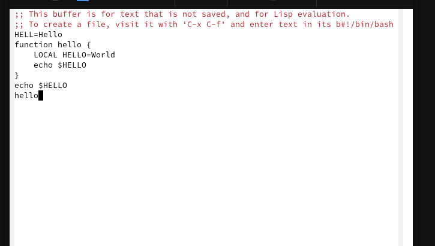

Figure 10: Копирование

## 4.11 Вставка области

`Ctrl+Y`

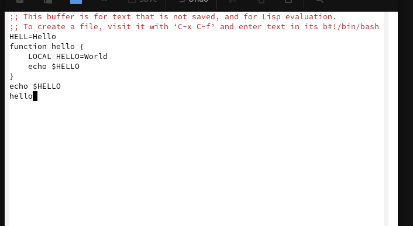

## 4.12 Перемещение в начало/конец строки

`Ctrl+A`, `Ctrl+E`

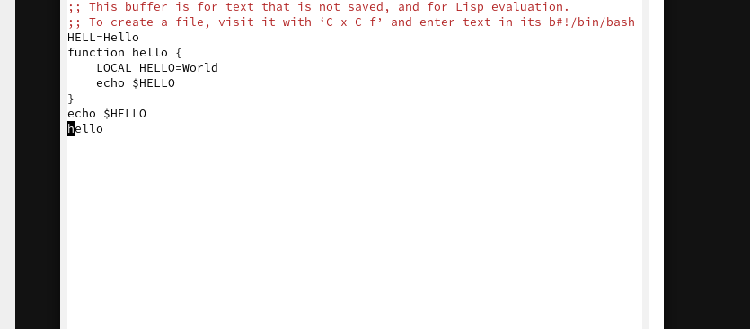

Figure 12: Строка

## 4.13 Перемещение в начало/конец файла

`M-<`, `M->`

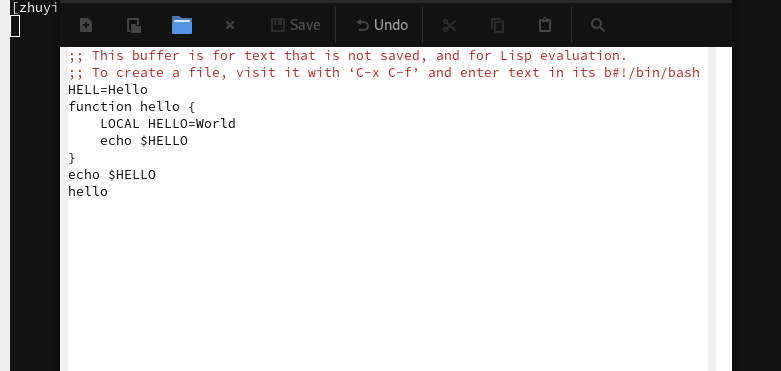

Figure 13: Файл

## 4.14 Поиск

`Ctrl+S`

[figure not shown]

Figure 14: Поиск

## 4.15 Поиск и замена

`M-%`

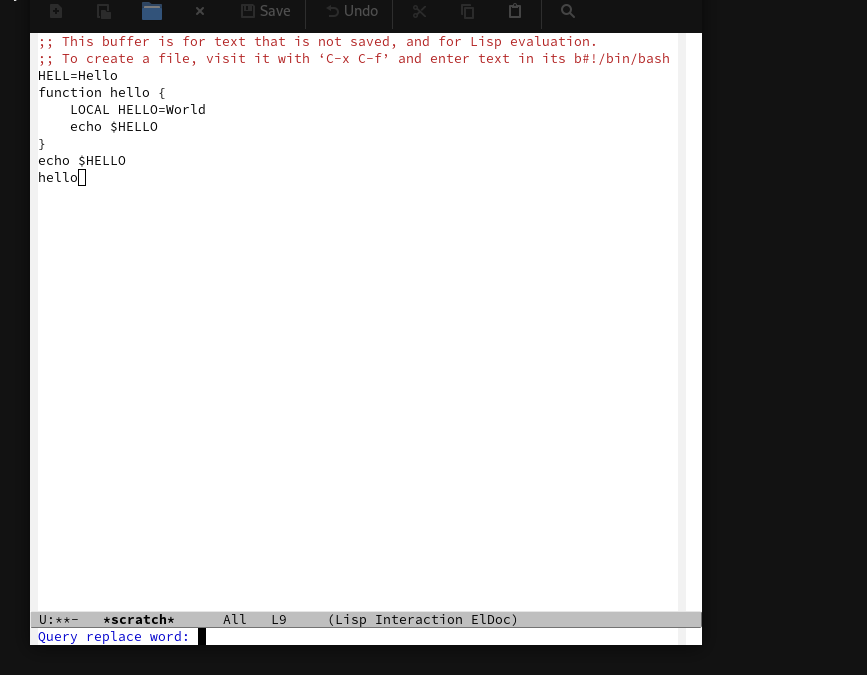

Figure 15: Замена

# 5 Выводы

В ходе работы изучен редактор Emacs, его основные термины (буфер, фрейм, окно), комбинации клавиш для перемещения курсора, работы с текстом, выделения, поиска, замены, работы с файлами и буферами.

# 6 Контрольные вопросы

**1. Кратко охарактеризуйте редактор Emacs.**

Emacs — мощный экранный редактор текста, написанный на языке Elisp.

**2. Особенности Emacs, сложные для новичка.**

Нестандартные комбинации клавиш, большое количество команд, режимы.

**3. Буфер и окно.**

Буфер — объект с текстом. Окно — прямоугольная область фрейма, отображающая один из буферов.

**4. Можно ли открыть больше 10 буферов?**

Да, ограничений нет.

**5. Буферы по умолчанию.**

`*scratch*`, `*Messages*`.

**6. Комбинации для ввода `C-c` и `C-c C-l`.**

`C-c` — префикс ввода основных команд. `C-c C-l` — вызов функции, зависящей от режима.

**7. Как поделить окно на две части?**

`C-x 2` — по горизонтали, `C-x 3` — по вертикали.

**8. Где хранятся настройки Emacs?**

`~/.emacs` или `~/.emacs.d/init.el`.

**9. Функция клавиши Enter.**

Вставка новой строки. Можно переназначить.

**10. Какой редактор удобнее?**

Emacs удобнее для сложной работы, vi — для быстрого редактирования. Каждый под свою задачу.

# 7 Список литературы

1. Курячий К. В. Операционная система UNIX. — М. : ИНТУИТ, 2016.
2. Робачевский А., Немнюгин С., Стесик О. Операционная система UNIX. — БХВ-Петербург, 2010.
3. Колисниченко Д. Н. Самоучитель системного администратора Linux. — БХВ-Петербург, 2011.